CS F364: Design and Analysis of Algorithms

# Greedy: Interval Scheduling

Lecture 13 |2026-06-05

Tulasimohan Molli

BITS Pilani, Hyderabad Campus

# Greedy Algorithms

- Greedy Algorithms
- Greedy Choice
- Algorithm & Correctness
- Properties & Summary

## Greedy Algorithm

- A **greedy algorithm** always makes the choice that looks best at the moment.
  - Everyday example: playing cards, investing in stocks, choosing a university.
  - The hope: a locally optimal choice will lead to a globally optimal solution.
  - For some problems, it works.
- Greedy algorithms tend to be easier to code and more efficient than DP.

## Interval Scheduling

- **Input:** A set of intervals $I = \{I_1, I_2, \dots, I_n\}$. Each interval $I_i = [s_i, f_i)$ with start $s_i$ and finish $f_i$.
- **Compatibility:** Two intervals are compatible if they do not overlap ($f_i \le s_j$ or $f_j \le s_i$).
- **Output:** A maximum-size subset of mutually compatible intervals.

CLRS (T1) refers to this problem as *Activity Selection*. The name *Interval Scheduling* (Kleinberg & Tardos) is more common.

## Example

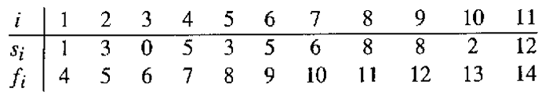

**Compatible Subsets:**

- $\{I_3, I_9, I_{11}\}$ (Size 3)
- $\{I_1, I_4, I_8, I_{11}\}$ (Size 4 — Optimal)
- $\{I_2, I_4, I_9, I_{11}\}$ (Size 4 — Optimal)

Goal: find a subset of **maximum size**.

## Interval Representation

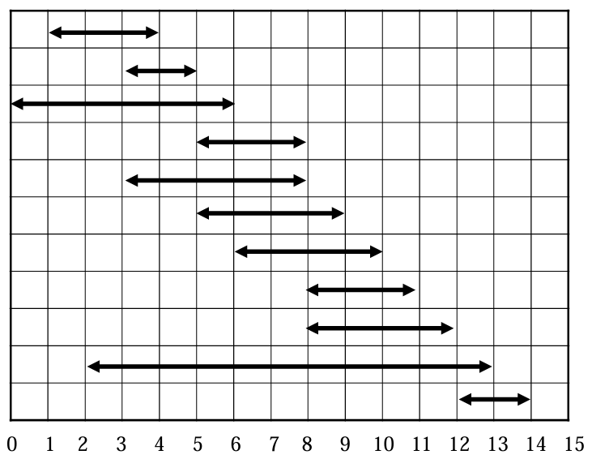

- Each activity is a half-open interval $[s_i, f_i)$.
- **Goal:** Select the maximum number of non-overlapping intervals.
- A classic scheduling problem with applications in resource allocation, classroom scheduling, CPU task execution, etc.

# Greedy Choice

- Greedy Algorithms
- Greedy Choice
- Algorithm & Correctness
- Properties & Summary

## Optimal Substructure (DP View)

Sort intervals by finish time: $f_1 \le f_2 \le \dots \le f_n$.

Define $S_{ij} = \{I_k : f_i \le s_k < f_k \le s_j\}$.

Let $c[i,j]$ be the maximum number of compatible intervals in $S_{ij}$:

$$c[i,j] = \begin{cases}
0 & \text{if } S_{ij} = \emptyset \\[4pt]
\displaystyle\max_{i < k < j} \big(c[i,k] + c[k,j] + 1\big) & \text{if } S_{ij} \ne \emptyset
\end{cases}$$

A DP solution would be $O(n^3)$ — but a greedy approach is simpler and faster.

## Greedy Choice

**Intuition:** Choose the interval that leaves the resource available for as many others as possible.

Which interval should we pick first?

- The one that **starts earliest**? ❌ (might be very long)
- The one that is **shortest**? ❌ (might overlap many)
- The one that **finishes earliest**? ✅

**Greedy choice:** Always pick the interval with the earliest finish time among the remaining compatible intervals.

## Failed Greedy Strategies

### 1. Earliest Start Time

Pick the interval that starts first.

**Counterexample:**

```
I_1: |-------------------------| (0 to 100)
I_2:   |---| (1 to 5)
I_3:         |---| (6 to 10)
```

- Greedy: $\{I_1\}$ (size 1)
- Optimal: $\{I_2, I_3\}$ (size 2)

### 2. Shortest Interval

Pick the interval with smallest duration $f_i - s_i$.

**Counterexample:**

```
I_1: |-------| (0 to 6)
I_2:      |---| (5 to 7 - shortest)
I_3:          |-------| (6 to 12)
```

- Greedy: $\{I_2\}$ (size 1)
- Optimal: $\{I_1, I_3\}$ (size 2)

## Why Earliest Finish?

Among all intervals, one must finish first in any optimal solution.

Picking the **earliest finish** leaves the maximum remaining time for other intervals.

After sorting by finish time, the greedy choice picks $I_1$ first.

# Algorithm & Correctness

- Greedy Algorithms
- Greedy Choice
- Algorithm & Correctness
- Properties & Summary

## Greedy Algorithm

```
Greedy-Interval-Scheduler(s, f):
    // Assumes f[1..n] is sorted in increasing order
    n = length(s)
    A = {I_1}
    k = 1
    for m = 2 to n:
        if s[m] >= f[k]:
            A = A ∪ {I_m}
            k = m
    return A
```

- **Time:** $\Theta(n)$ after sorting ($\Theta(n \log n)$ total with sort).
- **Space:** $O(1)$ auxiliary.

## Trace

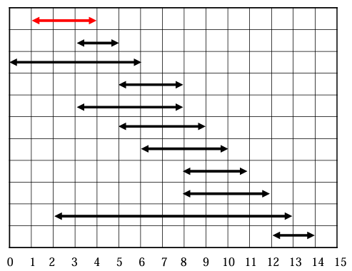

## Trace

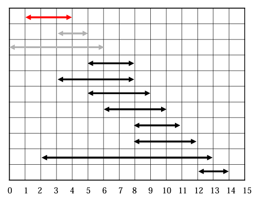

## Trace

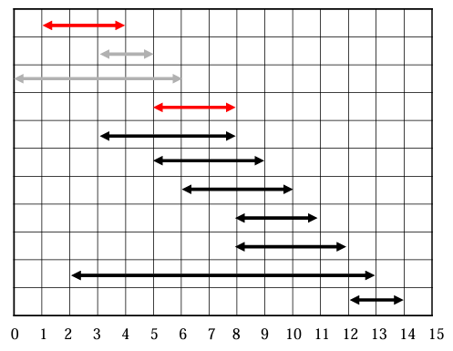

## Trace

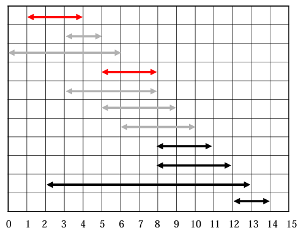

## Trace

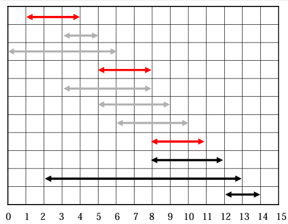

## Trace

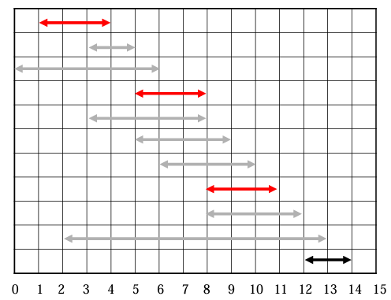

## Trace

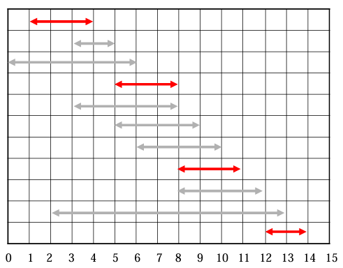

## Correctness Proof

Two parts:

1. **Greedy Choice Property:** There exists an optimal solution that includes the greedy choice.
2. **Optimal Substructure Property:** After making the greedy choice, the remaining problem is a smaller instance of the same type.

## Greedy Choice Property

**Lemma**

There exists an optimal solution $A$ such that the greedy choice $I_1$ (earliest finish) is in $A$.

**Proof.** Let $A$ be an optimal solution, ordered by finish time. Let $k_1$ be the first interval in $A$.

- If $k_1 = 1$: done — $A$ already includes the greedy choice.
- If $k_1 \ne 1$: construct $A' = (A \setminus \{k_1\}) \cup \{I_1\}$.

```
Original A:  |--- k_1 ---|   |--- k_2 ---|   |--- k_3 ---|
Greedy:      |-- I_1 --|

Modified A': |-- I_1 --|   |--- k_2 ---|   |--- k_3 ---|
```

Since $f_1 \le f_{k_1}$, $I_1$ cannot overlap with $k_2$ (as $s_{k_2} \ge f_{k_1} \ge f_1$).

$\therefore$ $A'$ is mutually compatible, $|A'| = |A|$, so $A'$ is also optimal. $\square$

## Optimal Substructure Property

**Note**

**Lemma:** If $A$ is an optimal solution, then $A' = A \setminus \{I_1\}$ is an optimal solution to $S' = \{I_i \in I : s_i \ge f_1\}$.

**Proof (Contradiction).**

- Suppose $\exists B'$ for $S'$ with $|B'| > |A'|$.
- Let $B = B' \cup \{I_1\}$.
- Since $B'$ only contains intervals starting after $f_1$, $I_1$ is compatible with all in $B'$.
- Then $B$ is a valid solution for $I$ with $|B| = |B'| + 1 > |A'| + 1 = |A|$, contradicting optimality of $A$. $\square$

# Properties & Summary

- Greedy Algorithms
- Greedy Choice
- Algorithm & Correctness
- Properties & Summary

## Properties of Greedy Algorithms

1. **Greedy Choice Property**
   - A globally optimal solution can be arrived at by making a locally optimal (greedy) choice.
2. **Optimal Substructure Property**
   - An optimal solution to the problem contains within it optimal solutions to subproblems.

These two properties must be proved for every greedy algorithm.

## Summary

- **Interval Scheduling** is a classic problem solvable by a greedy algorithm.
- **Greedy choice:** pick the interval with the earliest finish time.
- **Complexity:** $\Theta(n \log n)$ for sorting, $\Theta(n)$ for selection.
- **Correctness** relies on the greedy choice and optimal substructure properties.
- This pattern extends to many interval scheduling variants.